# 101.1. Uso de JupyterLab

Para la Plataforma Científica de Rubin en data.lsst.cloud.  
Divulgación de Datos: [Vista Previa de Datos 1](https://dp1.lsst.io)  
Tamaño del contenedor (Container size): small  
Versión de las Pipelines Científicas de LSST: r29.2.0  
Última verificación de ejecución: 2025-09-02  
Repositorio: github.com/lsst/tutorial-notebooks  
DOI: 10.11578/rubin/dc.20250909.20

**Objetivo de aprendizaje:** Cómo usar JupyterLab.

**Productos de datos LSST:** Ninguno.

**Paquetes:** Ninguno.

**Créditos:** Desarrollado originalmente por el equipo científico de la comunidad de Rubin. Por favor, considerar reconocer su trabajo si este *notebook* se utiliza para la preparación de artículos de revistas, lanzamientos de *software* u otros *notebooks*.

**Soporte:** Se invita a toda la comunidad a hacer preguntas o plantear problemas en la [Categoría de asistencia](https://community.lsst.org/c/support) del Foro de la Comunidad de Rubin. El equipo de Rubin responderá a todas las preguntas publicadas allí.

## 1. Introducción

La [Faceta Notebook](https://rsp.lsst.io/guides/notebooks/index.html) de la [Plataforma Científica de Rubin](https://rsp.lsst.io/index.html) es [JupyterLab](https://jupyter.org/), un entorno de software basado en un navegador para el acceso programático a datos y análisis.

Este notebook tutorial no importa ningún paquete de Python, no ejecuta ningún código ni accede a ningún dato. Sólo demuestra la funcionalidad básica de JupyterLab.

### 1.1. Documentación de RSP

Consultar el sitio de la [documentación de la Plataforma Científica de Rubin](https://rsp.lsst.io/index.html) para obtener información sobre cuentas de acceso a la plataforma, cuotas de almacenamiento y las capacidades generales de la RSP.

### 1.2. Documentación de JupyterLab

Consultar el sitio de [readthedocs de JupyterLab](https://jupyterlab.readthedocs.io/en/latest/) para más detalles sobre la funcionalidad de JupyterLab.

## 2. Iniciar una sesión de JupyterLab

Ir a [data.lsst.cloud](https://data.lsst.cloud/), seleccionar "Notebook Aspect" y seguir el proceso para iniciar sesión.

### 2.1. Opciones del servidor

Durante el inicio de sesión, se deben seleccionar las opciones del servidor, como se muestra en la Figura 1.

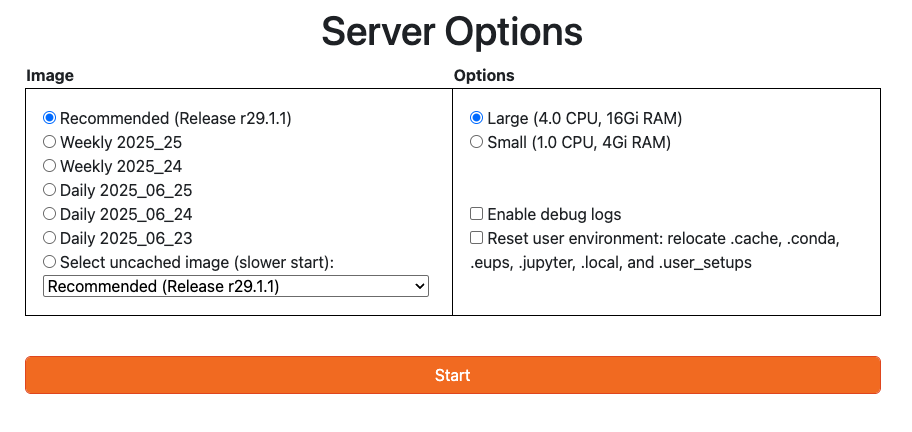

> **Figura 1:** Opciones del servidor, con la imagen recomendada (a junio de 2025) seleccionada y un tamaño de servidor grande "Large".

#### 2.1.1. Imagen

La opción de imagen del servidor corresponde a la versión del entorno de software (Pipelines Científicas de LSST - LSST Science Pipelines) que se usará en la sesión de JupyterLab.

**La imagen recomendada** ha sido seleccionada por el personal de Rubin como una versión estable, y la documentación y tutoriales de Rubin siempre se mantienen actualizados con la imagen recomendada.

La imagen recomendada se actualiza en escalas de semanas a meses, de manera que los cambios son incrementales y es más fácil para toda la comunidad evolucionar y mantener el código y la documentación.

Elegir siempre la imagen recomendada, a menos que se sepa que es necesaria una versión anterior o más reciente de las Pipelines Científicas de LSST (por ejemplo, si está reejecutando código personalizado antiguo o realizando trabajo de desarrollo).

**Las imágenes antiguas** están disponibles en el menú desplegable, pero no se conservan indefinidamente. Se recomienda actualizar el código personalizado para que funcione con la última imagen recomendada.

#### 2.1.2. Opciones

Las opciones corresponden al tamaño del servidor en términos de CPUs (Central Processing Units - unidades centrales de procesamiento) y RAM (Random Access Memory - memoria de acceso aleatorio, en gigabytes).

Seguir las siguientes indicaciones como guía general.

**Large** (grande): para recuperar y visualizar datos, ejecutar notebooks de tutoriales.

**Small** (pequeño): para simplemente navegar o editar archivos sin acceder a datos.

**Enable debug logs** (habilitar registros de depuración): no marcar esta casilla. El depurador [Debugger](https://jupyterlab.readthedocs.io/en/latest/user/debugger.html) no está habilitado en la Plataforma Científica de Rubin.

**Reset user environment** (restablecer entorno): marcar esta casilla para restaurar los archivos de configuración del *software* a los valores predeterminados (elimina *software* instalado por la persona usuaria).

### 2.2. Iniciar el servidor

Hacer clic en la barra naranja de la Figura 1 para iniciar el servidor.

La creación del servidor puede tardar unos minutos; más tiempo aún si se seleccionó una imagen antigua.

## 3. Área principal de trabajo

El área principal de trabajo, a la derecha en la Figura 2, ocupa la mayor parte del espacio de trabajo de JupyterLab y es donde aparecen los archivos abiertos. El explorador de archivos, a la izquierda en la Figura 2, se describe en la siguiente sección.

### 3.1. Página de bienvenida

La página de bienvenida siempre se mostrará primero y contiene varios enlaces útiles.

El archivo markdown para esta página es `/notebooks/tutorials/welcome.md`, y si se elimina accidentalmente, se crea automáticamente al iniciar sesión.

[figure not shown]

> **Figura 2:** La página de bienvenida, al 25 de junio de 2025. Esta página se actualizará con enlaces a las últimas divulgaciones de datos.

### 3.2. Lanzador

El lanzador es una pestaña en el área principal de trabajo que aparece de manera predeterminada después de cerrar la página de bienvenida.

De manera alternativa, se puede abrir el lanzador en cualquier momento haciendo clic en el botón azul **+** en la esquina superior izquierda.

[figure not shown]

> **Figura 3:** JupyterLab con la pestaña del lanzador abierta en el área principal de trabajo (al 25 de junio de 2025).

Hacer clic en cualquier panel para abrir un nuevo notebook, terminal, archivo de texto o markdown, script de Python, la interfaz de ayuda o el navegador de imágenes Firefly.

Los archivos y aplicaciones que se abran aparecerán en el área principal de trabajo en una nueva pestaña.

### 3.3. Notebooks tutoriales

Para abrir uno de los notebooks tutoriales de Rubin, hacer clic en **"Tutorials"** en la barra superior del menú (como se muestra en la Figura 2) y seleccionar un tutorial del menú desplegable.

Se abrirá en el área principal de trabajo una versión editable del tutorial, que se guardará en el directorio `notebooks/tutorials/`.

### 3.4. Visualización a pantalla dividida

Para abrir dos aplicaciones una al lado de la otra en lugar de como dos pestañas (parte superior de la Figura 4), hacer clic en la pestaña de la derecha y arrastrarla hacia abajo y a la derecha hasta que el cuadro azul transparente cubra la mitad del marco (parte central de la Figura 4), y soltar. Las dos aplicaciones quedarán una junto a la otra (parte inferior de la Figura 4).

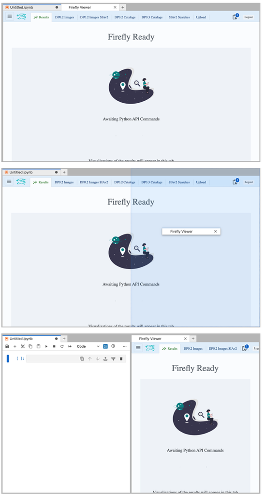

> **Figura 4:** Cómo ver dos aplicaciones lado a lado en el área principal de trabajo.

## 4. Explorador de archivos

La vista predeterminada en la barra lateral izquierda es el explorador de archivos, como se muestra en la Figura 2.

Hacer clic en la carpeta marcada con la flecha roja en la Figura 5 para volver al directorio principal.

Hacer doble clic en las carpetas y archivos de la lista para navegar por el sistema de archivos y abrir archivos.

Los archivos abiertos aparecerán en el área principal de trabajo en una nueva pestaña.

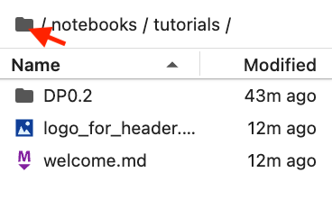

> **Figura 5:** Detalle del menú del explorador de archivos. Hacer clic en el pequeño símbolo de carpeta marcado con la flecha roja para volver a al directorio de inicio (*home directory*). Hacer doble clic en las carpetas y archivos de la lista para abrirlos en el área principal de trabajo.

## 5. Terminal

Usar el lanzador para abrir una terminal.

La terminal se abrirá en el mismo directorio que muestra el explorador de archivos en la barra lateral izquierda.

Escribir `ls` y presionar la tecla *Enter* (Entrar) para listar el contenido del directorio.

En el ejemplo mostrado en la Figura 6, la terminal fue iniciada mientras el explorador de archivos estaba en la carpeta `/notebooks/tutorials`.

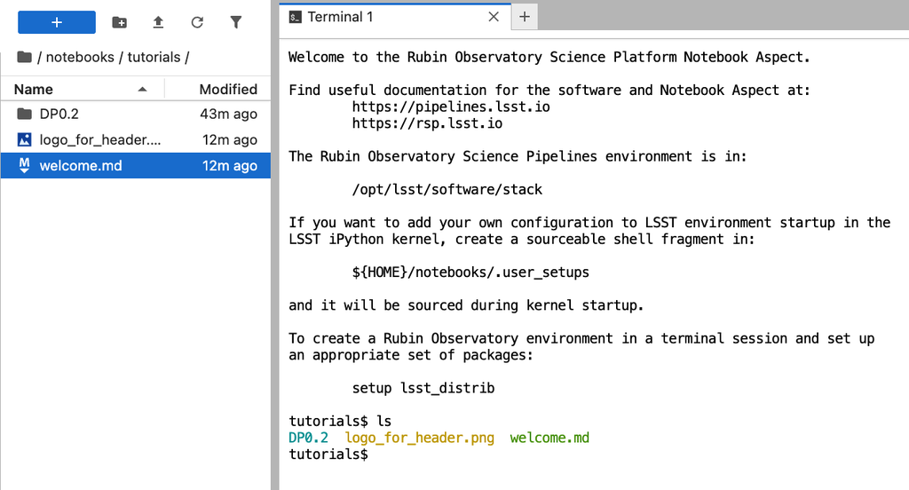

> **Figura 6:** La interfaz de la terminal.

### 5.1. Personalizar el *prompt*

Este cambio respecto al valor predeterminado se logró añadiendo lo siguiente al archivo `/.bashrc`:

```
# Alias y funciones específicas
PS1='\W\$ '
```

### 5.2. Crear un entorno de Rubin en una terminal

Como sugiere cada terminal recién abierta, para crear un entorno del Observatorio Rubin en una sesión de terminal y acceder al *Butler* y a las *Pipelines Científicas de LSST* desde la línea de comandos, ejecutar:

```
setup lsst_distrib
```

## 6. Cambiar a modo oscuro

Ir a la configuración en **"Settings"**, luego **"Theme"** para visualizar los distintos temas, y seleccionar **"JupyterLab Dark"**.

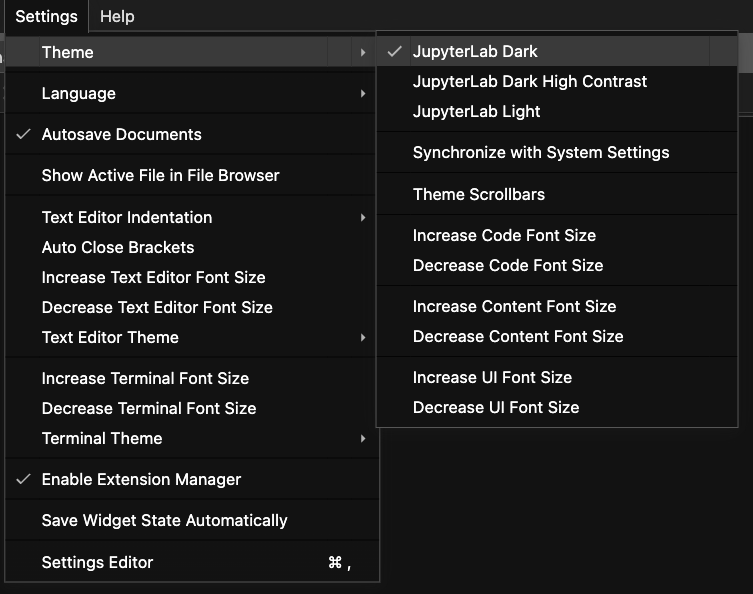

> **Figura 7:** Cómo cambiar al modo oscuro.

## 7. Apagar el servidor

Se recomienda siempre guardar y cerrar todos los archivos, y elegir el menú de archivo “File” y luego la opción para guardar todo, salir y cerrar sesión “Save all, exit, and log out” al final de cada sesión.

Esto es importante para preservar recursos para otras personas y para garantizar que cada vez que se ingrese nuevamente al RSP se haga en un estado conocido.

Para ayudar a evitar problemas con instancias obsoletas, las sesiones se cerrarán automáticamente después de 5 días de inactividad, o después de 25 días.